# explanatory slides

## Investigation Overview

> In this slideshow, we will focus on analyzing user type v.s. duration relationship on the bike data.

## Dataset Overview

> Ford GoBike serves bicycle sharing service.  
> The data was collected from 2019-02-01 to 2019-02-28. There are 183,412 bike records in the dataset with 16 features.  
> The features we used in here are: user_type, duration_sec, member_birth_year, weekday(extracted from start_time)

## User type: Subscriber v.s. Customer

> Nearly 90% of the users are Subscriber, others are Customer.  
> “Subscriber” = Member or “Customer” = Casual

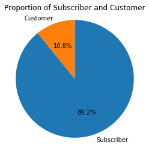

```python
sorted_counts = bike_copy['user_type'].value_counts()
plt.pie(sorted_counts, labels = sorted_counts.index, startangle = 90, counterclock = False, autopct='%1.1f%%');
plt.title('Proportion of Subscriber and Customer')
plt.axis('square');
```

## Week day usage

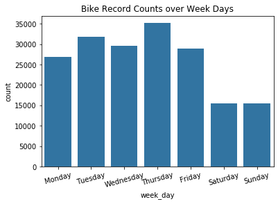

```python
order = ['Monday', 'Tuesday', 'Wednesday', 'Thursday', 'Friday', 'Saturday', 'Sunday']
sb.countplot(data=bike_copy, x='week_day', color=base_color, order=order);
plt.xticks(rotation=15);
plt.title('Bike Record Counts over Week Days');
```

## User type v.s. Duration

> Customer's bike usage range is wider than Subscriber after log transformation.

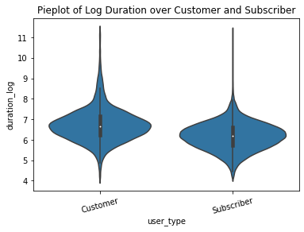

```python
sb.violinplot(data=bike_copy, x='user_type', y='duration_log', color=base_color, innner=None)
plt.xticks(rotation=15);
plt.title('Pieplot of Log Duration over Customer and Subscriber');
```

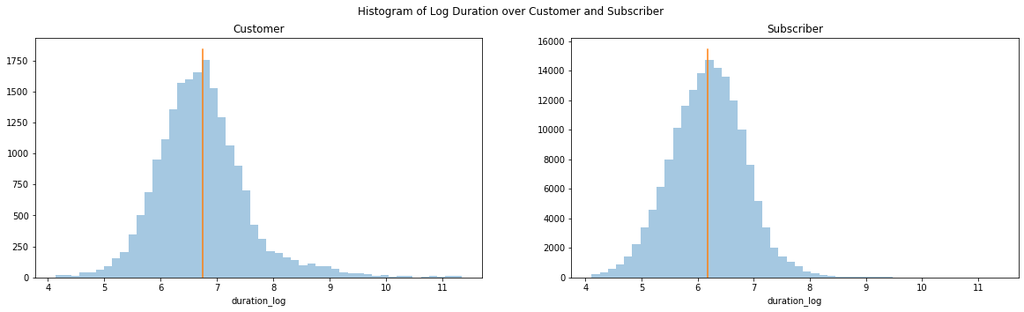

```python
plt.figure(figsize = [20, 5])
plt.suptitle('Histogram of Log Duration over Customer and Subscriber');
ax1 = plt.subplot(1, 2, 1)
sb.distplot(customer['duration_log'], kde=False, rug=False);
ax1.title.set_text('Customer')
ax1.plot([customer['duration_log'].mean(),customer['duration_log'].mean()], ax1.get_ylim())
ax2 = plt.subplot(1, 2, 2)
sb.distplot(subscriber['duration_log'], kde=False, rug=False);
ax2.title.set_text('Subscriber')
ax2.plot([subscriber['duration_log'].mean(),subscriber['duration_log'].mean()], ax2.get_ylim());
```

## User type v.s. Duration v.s. member_birth_day

> Adding member_birth_day in analysis, Subsciber's bike duration is significantly lower than Customer's bike duration.

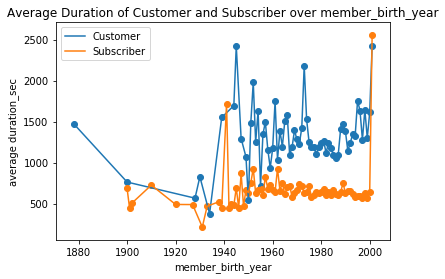

```python
fig, ax = plt.subplots()
type_list = bike_nona['user_type'].unique()
for i, utype in np.ndenumerate(type_list):
    line_color = sb.color_palette()[i[0]]
    bike_type = bike_nona[ bike_nona['user_type']==utype ]
    year = np.sort(bike_type['member_birth_year'].unique())
    year_dur_mean = bike_type.groupby('member_birth_year').mean()['duration_sec']
    ax.errorbar(x=year, y=year_dur_mean, c=line_color, label=utype);
    ax.scatter(x=year, y=year_dur_mean);
ax.legend();
ax.set_xlabel("member_birth_year")
ax.set_ylabel("average duration_sec");
plt.title('Average Duration of Customer and Subscriber over member_birth_year');
```

## User type v.s. Duration v.s. week_day

> For Subscribers, their average durations are quite stable, with only a little increase on weekends.  
> For Customers, their average durations are much longer than Subsribers. Their weekend usage time also has large growth.

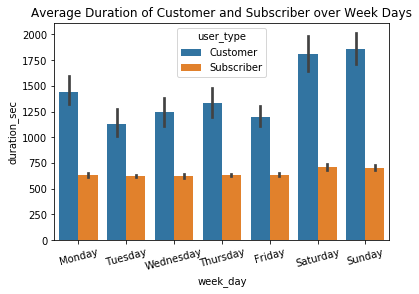

```python
order = ['Monday', 'Tuesday', 'Wednesday', 'Thursday', 'Friday', 'Saturday', 'Sunday']
sb.barplot(data=bike_copy, x='week_day', y='duration_sec', hue='user_type', order=order)
plt.xticks(rotation=15);
plt.title('Average Duration of Customer and Subscriber over Week Days');
```